# Estimation d’une taille de population à partir de données de capture-marquage-recapture

Guillaume - Leonardo

21/05/2021

## Introduction

Dans ce projet, on étudie les méthodes de capture-marquage-recapture à travers plusieurs hypothèses et 2 approches : approche fréquentiste et approche bayésienne. Ces méthodes ont pour but d’évaluer le nombre d’individus d’une population, noté $N$, à travers un échantillonage non destructif. La probabilité de capture d’un individu est notée $\pi$ et est appelée efficacité. Elle dépend de beaucoup de paramètres relatifs au contexte de l’expérience. Dans notre projet, on se place dans un contexte de pêche d’un poisson d’intérêt.

Dans une première partie, on définit le modèle probabiliste, noté $\mathcal{M}$, que l’on va utiliser et on calcule sa log-vraisemblance. On va également créer une fonction pour générer un échantillon de ce modèle à l’aide de la méthode d’inverse générique. Dans la deuxième partie, on suppose $N$ connu et on cherche à estimer $\pi$. Pour ce faire, on va s’intéresser à l’estimateur du maximum de vraisemblance du modèle $\mathcal{M}$ et à la construction d’une loi a posteriori. Dans la troisième partie, on cherche à estimer $N$ sans que $\pi$ soit connu. On utilisera une approche fréquentiste à travers l’estimateur de Petersen, puis une approche bayésienne, avec l’utilisation d’un algorithme MCMC.

## Pour commencer…

Introduisons des notations :

- $N$ le nombre de poissons dans le lac.
- $\pi$ l’efficacité, c’est-à-dire la probabilité de pêcher un poisson d’intérêt.
- $C_1$ et $C_2$ le nombre total de poissons capturés et marqués lors des pêches 1 et 2 respectivement.
- $C_{20}$ le nombre de poissons non marqués capturés lors de la deuxième pêche et $C_{21}$ le nombre de poissons marqués capturés lors de la deuxième pêche. On a donc : $C_2 = C_{20} + C_{21}$.

On considère le modèle probabiliste $\mathcal{M}$ suivant :

$$C_1 \sim Binomial(N,\pi) \\
C_{20}|C_1 \sim Binomial(N-C_1,\pi) \\
C_{21}|C_1 \sim Binomial(C_1,\pi)$$

$$\\[0.1cm]$$

**Question 1 :** Montrer que la log-vraisemblance du modèle probabiliste $\mathcal{M}$ s’écrit :

$$\log([C_1 = c_1, C_{20} = c_{20}, C_{21} = c_{21} | \pi, N]) = \log(C_N^{c_1}C_{n-c_1}^{c_{20}}C_{c_1}^{c_{21}}) + (c_1 + c_2)\log(\pi) + (2N - c_1 - c_2)\log(1 - \pi)$$

$$\\[0.1cm]$$

**Remarque préliminaire :** On met de côté les cas pathologiques $\pi = 0$ et $\pi = 1$ pour pouvoir calculer la log-vraisemblance de $\mathcal{M}$. De plus, ces cas ne sont pas intéressants à étudier (aucune chance de pêcher un poisson ’intérêt et aucune chance de ne pas en pêcher un).

La vraisemblance du modèle probabiliste $\mathcal{M}$ est : $[C_1 = c_1, C_{20} = c_{20}, C_{21} = c_{21} | \pi, N]$.

$C_{20}|C_1$ et $C_{21}|C_1$ sont conditionnellement dépendantes de $C_1$ par construction. Donc, par densité jointe de variables conditionnellement dépendantes, on a

$$[C_1 = c_1, C_{20} = c_{20}, C_{21} = c_{21} | \pi, N] = [C_1 = c_1| \pi, N] \cdot [C_{20} = c_{20}, C_{21} = c_{21} | C_1 = c_1, \pi, N]$$

Comme $C_{20}|C_1$ et $C_{21}|C_1$ sont indépendantes, on a

$$[C_1 = c_1, C_{20} = c_{20}, C_{21} = c_{21} | \pi, N] = [C_1 = c_1| \pi, N] \cdot [C_{20} = c_{20} | C_1 = c_1, \pi, N] \cdot [C_{21} = c_{21} | C_1 = c_1, \pi, N]$$

La densité d’une loi binomiale $X \sim Binomial(n,p)$ est $[X=k] = C_n^k p^k (1-p)^{n-k}$. Donc

$$\begin{align}
& [C_1 = c_1| \pi, N] \cdot [C_{20} = c_{20} | C_1 = c_1, \pi, N] \cdot [C_{21} = c_{21} | C_1 = c_1, \pi, N] \\
& = C_N^{c_1} \pi^{c_1} (1-\pi)^{N-c_1} \cdot C_{N-c_1}^{c_{20}} \pi^{c_{20}} (1-\pi)^{N-c_1-c_{20}} \cdot C_{c_1}^{c_{21}} \pi^{c_{21}} (1-\pi)^{c_1-c_{21}} \\
& = C_N^{c_1} C_{N-c_1}^{c_{20}} C_{c_1}^{c_{21}} \cdot \pi^{c_1 + c_{20} + c_{21}} \cdot (1-\pi)^{2N - c_1 - c_{20} - c_{21}} \\
& = C_N^{c_1} C_{N-c_1}^{c_{20}} C_{c_1}^{c_{21}} \cdot \pi^{c_1 + c_{2}} \cdot (1-\pi)^{2N - c_1 - c_{2}} ~~ \text{ car } c_2 = c_{20} + c_{21}
\end{align}$$

Finalement, comme $\log(a \cdot b) = \log(a) + \log(b)$ et $\log(a^b) = b\cdot \log(a)$, la log-vraisemblance du modèle probabiliste $\mathcal{M}$ est bien

$$\log([C_1 = c_1, C_{20} = c_{20}, C_{21} = c_{21} | \pi, N]) = \log(C_N^{c_1}C_{N-c_1}^{c_{20}}C_{c_1}^{c_{21}}) + (c_1 + c_2)\log(\pi) + (2N - c_1 - c_2)\log(1 - \pi)$$

$$\\[0.1cm]$$

**Question 2 :** Pour tout $u \in [0,1]$, écrire l’expression de l’inverse généralisée de la fonction de répartition de la variable aléatoire $C_1$ de loi $Binomial(N,\pi)$. En déduire une fonction R qui génère par inversion générique en tirages indépendants de la variable aléatoire $C_1$. Utiliser cette fonction pour tirer un échantillon de $n = 10000$ réalisations de loi $Binomial(125,0.15)$. Comparer les fréquences obtenues avec les fréquences théoriques.

$$\\[0.1cm]$$

Soit $X$ une variable aléatoire de fonction de répartition $F$. L’inverse généralisée $F^{-1}$ est

$$F^{-1}(u) = \inf\{ x \in \mathbb{R} ; u \leq F(x) \} \quad \text{ pour } u \in [0,1]$$

Comme $C_1 \sim Binomial(N,\pi)$, sa fonction de répartition est

$$F(x)={\mathbb P}(X\leq x)={\begin{cases}1&si\;x\geq n\\\displaystyle \sum _{{k=0}}^{{\lfloor x\rfloor }}{n \choose k}p^{k}(1-p)^{{n-k}}&si\;0\leq x<n\\0&si\;x<0\end{cases}}$$

Il n’y a pas de formule exacte pour trouver l’inverse généralisée $F^{-1}$. On utilise donc une méthode incrémentale qui se base sur la croissance de $F$ et sur le fait que $F$ est constante sur $[\lfloor x\rfloor , \lfloor x\rfloor + 1[$. On trouve $x$ en calculant pour $x=0,1,2,...$ croissant jusqu’à ce qu’on trouve le premier $x$ qui satisfait $u \leq F(x)$.

On utilise maintenant la méthode d’inversion de la fonction de répartition pour créer une fonction génératrice de la variable $C_1 \sim Binomial(N,\pi)$. On crée une fonction $\verb!notre.dbinom(k, prob, N)!$, densité de $Binomial(N, \verb!prob!)$ évaluée en $\verb!k!$. On l’utilise dans le calcul de $F^{-1}$.

```r
#densité de la loi binomiale(N,prob) évaluée en k
notre.dbinom <- function(k, prob, N){
  return(choose(N, k)*(prob^k)*((1 - prob)^(N-k)))
}

#inverse généralisée de la fonction de répartition de la loi binomiale(N,prob)
notre.qbinom <- function(u, N, prob){
  densites <- sapply(c(0:N), FUN = notre.dbinom, prob, N)
  sommes <- sapply(c(1:N+1), function(x) {sum(densites[1:x])})
  return(min(which(u <= sommes, arr.ind = T)))
}
```

Pour vérifier et étudier notre code, on génère un échantillon de $n=10000$ réalisations de loi $Binomial(125,0.15)$. Pour ce faire, on crée la fonction $\verb!notre.rbinom(n,N,prob)!$ qui génère $n$ réalisation de la loi $Binomial(\verb!N!,\verb!prob!)$. C’est l’équivalent de la fonction $\verb!rbinom!$ de R. On compare les fréquences obtenues avec les fréquences théoriques en représentant l’histogramme de nos observations obtenues avec la densité théorique codée dans R.

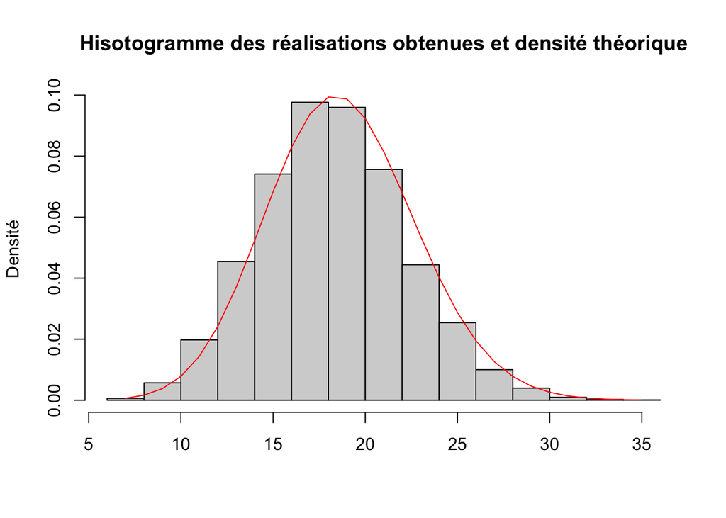

```r
#fonction générant un échantillon n de la loi binomiale(N,prob)
notre.rbinom <- function(n, N, prob){
  U = runif(n)
  return(sapply(U, FUN = notre.qbinom, N = N, prob = prob))
}

#simulation d'un n-échantillon de la loi binomiale(125,0.15)
val_obtenues <- notre.rbinom(10000, 125, 0.15)

#densité théorique de la loi binomiale(125,0.15) sur les valeurs prises parmi
#les n = 10000 réalisations précédentes
xfit<-seq(min(val_obtenues),max(val_obtenues))
yfit<-dbinom(size = 125,prob = 0.15, x = xfit)

#représentation de l'histogramme des n = 10000 réalisations obtenus et
#superposition de la densité théorique
hist(val_obtenues, freq = F,ylim=c(0,max(yfit)),main = "Hisotogramme des réalisations obtenues et densité théorique",ylab="Densité",xlab="")
lines(xfit,yfit,col='red')
```

On remarque que la densité se superpose parfaitement avec l’histogramme des $n=10000$ réalisations. On considère donc que le code est vérifié et que la méthode d’inversion nous permet de générer des tirages indépendants de la loi $Binomial(N,\pi)$.

$$\\[0.1cm]$$

**Question 3 :** Utiliser la fonction R précédente pour définir une seconde fonction R permettant de générer des réalisations possibles de capture-marquage-recapture (i.e. des variables aléatoires $C_1$, $C_{20}$ et $C_{21}$) selon le modèle $\mathcal{M}$.

$$\\[0.1cm]$$

Grâce à la fonction $\verb!notre.rbinom!$ (où $n=1$), on peut simuler une réalisation de $C_1$. Or, $C_{20}|C_1$ et $C_{21}|C_1$ sont dépendantes conditionnement à $C_1$, donc on peut les simuler grâce à la réalisation de $C_1$. On code la fonction $\verb!realisations!$ qui génère une réalisation du modèle $\mathcal{M}$.

```r
#fonction générant une réalisation du modèle M
realisations <- function(N, prob){
  C1 <- notre.rbinom(n = 1, N = N, prob = prob)
  C20 <- notre.rbinom(n = 1, N = N - C1, prob = prob)
  C21 <- notre.rbinom(n = 1, N = C1, prob = prob)
  return(c(C1, C20, C21))
}
```

## Supposons N connu

Supposons tout d’abord $N=950$ (connu) et estimons l’efficacité $\pi$.

$$\\[0.1cm]$$

**Question 4 :** Calculer l’estimateur du maximum de vraisemblance $\hat{\pi}_{MLE}$ du paramètre $\pi$. Sachant les données observées, en déduire une estimation de $\pi$.

$$\\[0.1cm]$$

Reprenons la log-vraisemblance du modèle $\mathcal{M}$ de la question 1 :

$$\log([C_1 = c_1, C_{20} = c_{20}, C_{21} = c_{21} | \pi, N]) = \log(C_N^{c_1}C_{N-c_1}^{c_{20}}C_{c_1}^{c_{21}}) + (c_1 + c_2)\log(\pi) + (2N - c_1 - c_2)\log(1 - \pi)$$

Etant donné que $N$ est connu, c’est une fonction de $\pi$. On la note $\mathcal{\log L}$ où $\mathcal{L}$ est la vraisemblance.

$$\log \mathcal{L} (\pi) = \log(C_N^{c_1}C_{N-c_1}^{c_{20}}C_{c_1}^{c_{21}}) + (c_1 + c_2)\log(\pi) + (2N - c_1 - c_2)\log(1 - \pi)$$

On cherche $\hat{\pi}_{MLE}$ maximisant la log-vraisemblance $\log \mathcal{L}$. Calculons la dérivée :

$$\begin{align}
\frac{\partial \log \mathcal{L}(\pi)}{\partial \pi} & = \frac{c_1 + c_2}{\pi} - \frac{2N - c_1 - c_2}{1-\pi} \\
& = \frac{c_1 - \pi c_1 + c_2 - \pi c_2 - 2 \pi N + \pi c_1 + \pi c_2}{\pi (1-\pi)} \\
& = \frac{c_1 + c_2 - 2 \pi N}{\pi (1-\pi)}
\end{align}$$

On a

$$\frac{\partial \log \mathcal{L}(\pi)}{\partial \pi} = 0 \Longleftrightarrow \pi = \frac{1}{N} \left( \frac{c_1 + c_2}{2} \right)$$

On prend donc $\frac{1}{N} \left( \frac{c_1 + c_2}{2} \right)$ le candidat de $\hat{\pi}_{MLE}$.

Vérifions que c’est bien un maximum de $\log \mathcal{L}$. On calcule sa dérivée seconde :

$$\frac{\partial^2 \log \mathcal{L}(\pi)}{\partial \pi^2} = - \frac{c_1 + c_2}{\pi^2} - \frac{2N - c_1 - c_2}{(1 - \pi)^2}$$

On fait une disjonction de cas selon les valeurs de $c_1$ :

- Si $c_1 = 0$, alors $c_2 = 0$, $- \frac{c_1 + c_2}{\pi^2} = 0$ et $- \frac{2N - c_1 - c_2}{(1 - \pi)^2} < 0$. Donc $\frac{\partial^2 \log \mathcal{L}(\pi)}{\partial \pi^2} < 0$.
- Si $c_1 = N$, alors $c_2 \leq N$, $- \frac{c_1 + c_2}{\pi^2} < 0$ et $- \frac{2N - c_1 - c_2}{(1 - \pi)^2} \leq 0$. Donc $\frac{\partial^2 \log \mathcal{L}(\pi)}{\partial \pi^2} < 0$.
- Si $c_1 \in ~ ]0 , N[$, alors $c_2 < N$, $- \frac{c_1 + c_2}{\pi^2} < 0$ et $- \frac{2N - c_1 - c_2}{(1 - \pi)^2} < 0$. Donc $\frac{\partial^2 \log \mathcal{L}(\pi)}{\partial \pi^2} < 0$.

Dans tous les cas, $\frac{\partial^2 \log \mathcal{L}(\pi)}{\partial \pi^2} < 0$. Finalement, $\hat{\pi}_{MLE}$ est bien un maximum de $\log \mathcal{L}$, donc de $\mathcal{L}$. C’est l’estimateur du maximum de vraisemblance du paramètre $\pi$.

Sachant les données observées $N = 950$, $C_1 = 125$, $C_{20} = 134$ et $C_{21} = 21$, on déduit l’estimation de $\pi$ suivante :

$$\hat{\pi}_{MLE} = \frac{1}{950} \left( \frac{125 + 155}{2} \right) = 0.1473684$$

$$\\[0.1cm]$$

**Question 5 :** Assignons une loi a priori $beta(\alpha,\beta)$ sur le paramètre $\pi$. Montrer que la loi a posteriori de $\pi$ sachant $N$ notée $[\pi|N,C_1,C_{20},C_{21}]$ est alors une loi beta de paramètres $C_1+C_2+\alpha$ et $2N - C_1 - C_2+\beta$. Donner l’expression de l’espérance de cette loi beta. Que remarquez-vous ?

$$\\[0.1cm]$$

On choisit d’attribuer une loi a priori $beta(\alpha,\beta)$ sur le paramètre $\pi$. Le choix de cette loi est motivé par son support sur $[0,1]$ (i.e. les valeurs possibles de $\pi$) et sa grande variété de formes possibles. Cette loi a priori définit une distribution des valeurs “plausibles” de $\pi$ avant considération de nos données $N, C_1, C_{20}, C_{21}$. On ajoute l’information de nos données en calculant la loi a posteriori de $\pi$ sachant $N, C_1, C_{20}, C_{21}$, i.e. $[\pi | N, C_1, C_{20}, C_{21}]$. Elle est donnée par le théorème de Bayes :

$$[\pi | N, C_1, C_{20}, C_{21}] \propto \mathcal{L} (N,C_1,C_{20},C_{21}|\pi) \cdot [\pi]$$
Or on a

$$\mathcal{L} (N,C_1 = c_1,C_{20} = c_{20},C_{21} = c_{21}|\pi) = C_N^{c_1} C_{N-c_1}^{c_{20}} C_{c_1}^{c_{21}} \cdot \pi^{c_1+c_2} \cdot (1-\pi)^{2N-c_1-c_2}$$

et

$$[\pi] = K \cdot \pi^{\alpha - 1} \cdot (1-\pi)^{\beta - 1}$$

où $K$ est une constante de normalisation qui ne dépend pas de $\pi$. Donc

$$\mathcal{L} (N,C_1 = c_1,C_{20} = c_{20},C_{21} = c_{21}|\pi) \cdot [\pi] = \underbrace{K \cdot C_N^{c_1} C_{N-c_1}^{c_{20}} C_{c_1}^{c_{21}}}_{=\tilde{K}} \cdot \pi^{c_1+c_2+\alpha-1} \cdot (1-\pi)^{2N-c_1-c_2+\beta-1}$$

où $\tilde{K}$ est une constante indépendante de $\pi$. On en déduit que

$$\pi|N,C_1,C_{20},C_{21} \sim Beta(C_1+C_2+\alpha,2N-C_1-C_2+\beta)$$

et son espérance est

$$\mathbb{E} [\pi | N,C_1,C_{20},C_{21}] = \frac{C_1 + C_2 + \alpha}{2N + \alpha + \beta}$$

On remarque 2 choses :

- Si $c_1 = c_2 = 0$, c’est-à-dire si on ne pêche aucun poisson d’intérêt lors des 2 captures, alors $\mathbb{E} [\pi | N,C_1,C_{20},C_{21}] = \frac{\alpha}{2N + \alpha + \beta} > 0$. Autrement dit, l’espérance de pêche est non nulle sachant que l’on a rien pêché lors des 2 tentatives.
- Si $c_1 = c_2 = N$, c’est-à-dire si on pêche tous les poissons d’intérêt lors des 2 captures, alors $\mathbb{E} [\pi | N,C_1,C_{20},C_{21}] = \frac{2N + \alpha}{2N + \alpha + \beta} < 1$. Autrement dit, même si on pêche tous les poissons d’intérêt du lac les 2 fois, alors l’espérance de pêche n’est pas optimale (n’est pas égale à 1).

$$\\[0.1cm]$$

**Question 6 :** Posons $\alpha=1$ et $\beta=3$. Représenter sur un même graphe les densités a priori et a posteriori de $\pi$ ainsi que l’estimateur du maximum de vraisemblance de $\hat{\pi}_{MLE}$. Commenter les résultats.

$$\\[0.1cm]$$

On pose $\alpha=1$ et $\beta=3$. On représente sur un même graphe les densités a priori et a posteriori de $\pi$ ainsi que l’estimateur du maximum de vraisemblance de $\hat{\pi}_{MLE}$ :

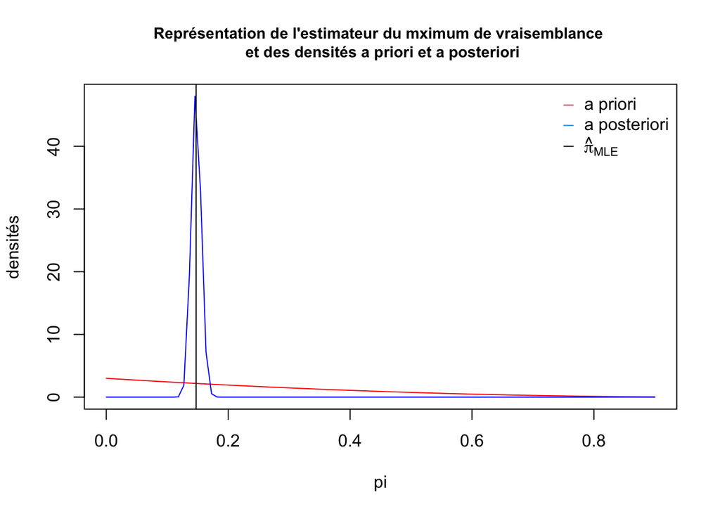

```r
#paramètres de la loi beta(alpha,beta)
alpha = 1
beta = 3

#nombre de poissons d'intérêt
N = 950

#nombre de poissons pêchés
c_1 = 125
c_2 = 155

#estimateur du maximum de vraisemblance
hat_pi_MLE = (1/N)*((c_1+c_2)/2)

#on récupère le max des bornes supérieures des supports des densités a priori et
#a posteriori ainsi que l'estimateur du maximum de vraisemblance
pi_max = max( qbeta(.999,alpha,beta), qbeta(.999,c_1+c_2+alpha,2*N-c_1-c_2+beta), hat_pi_MLE)

#on crée le support
ll = seq(0, pi_max, length.out=100)

#on calcule les densités a priori et a posteriori sur le support
a_priori = dbeta(ll,alpha,beta)
a_posteriori = dbeta(ll,c_1+c_2+alpha,2*N-c_1-c_2+beta)

#on défini la valeur maximale pour déterminer l'échelle du plot
y_max = max(a_priori,a_posteriori)

#on représente la densité a priori et a posteriori
plot(ll, a_priori, col='red', type='l', ylim = c(0,y_max), ylab="densités", xlab="pi", main = "Représentation de l'estimateur du mximum de vraisemblance \n et des densités a priori et a posteriori", cex.main = 0.9)
lines(ll,a_posteriori, col='blue')

#on ajoute l'estimateur du maximum de vraisemblance
abline(v=hat_pi_MLE)

#on ajoute la légende
legend("topright", legend=c("a priori", "a posteriori", TeX("$\\hat{\\pi}_{MLE}$")), bty='n', pch=rep('_',3), col=c(2,4,1))
```

On en conlut que si $N$ est connu, à l’aide du modèle de capture-marquage-recapture et de la loi a priori de $\pi$, on peut créer une loi a posteriori qui s’adapte très bien aux données et à la loi a priori $Beta(1,3)$ qui permet d’estimer l’efficacité $\pi$.

## Supposons N et $\pi$ inconnus

### Approche fréquentiste

Pour évaluer le nombre d’individus N dans une population d’intérêt à partir de deux expériences de pêche de type capture-marquage-recapture, un estimateur fréquentiste naïf est l’estimateur de “Petersen” défini par :

$$\hat{N} = \frac{C_1 C_2}{C_{21}}$$

$$\\[0.1cm]$$

**Question 7 :** Appliquer cet estimateur au jeu de données réelles observées afin d’estimer le nombre de “poissons” $N$ dans “le lac”.

$$\\[0.1cm]$$

Dans la construction de l’estimateur de Petersen, on suppose que la proportion de poissons marqués après la deuxième capture doit refléter la proportion de poissons marqués dans l’ensemble de la population, c’est-à-dire

$$\frac{C_1}{N} = \frac{C_{21}}{C_2}$$

D’où l’estimateur de Petersen suivant :

$$\hat{N} = \frac{C_1 C_2}{C_{21}}$$

Avec les valeurs du jeu de données réelles observées, on a

$$\hat{N} = \frac{125 \times 155}{21} = 922.619$$
L’estimateur de Petersen du nombre de “poissons” $N$ dans “le lac” est $\hat{N} = 922.619$.

$$\\[0.1cm]$$

**Question 8 :** Supposons ici que les “vraies” valeurs des paramètres soient $N_{true} = 923$ et $\pi_{true}= 0.15$. Simuler 100 jeux de données à l’aide de la fonction implémentée à la question 3, en déduire 100 estimations du paramètre $N$ puis estimer empiriquement - par Monte-Carlo - le biais relatif de $\hat{N}$. Recommencer en faisant varier $N_{true}$ de 100 à 1000 par pas de 10 puis représenter l’évolution du biais relatif en fonction de $N_{true}$. Discuter des résultats.

$$\\[0.1cm]$$

On fait l’hypothèse et le choix d’arrondir l’estimateur de Pertersen : on suppose que les “vraies” valeurs des paramètres sont $N_{true} = 923$ et $\pi_{true}= 0.15$, que l’on note $\verb!N_true!$ et $\verb!pi_true!$ dans le code.

```r
N_true <- 923
pi_true <- 0.15
```

On veut étudier le biais de l’estimateur de Petersen $\hat{N}$ défini par $Biais(\hat{N}) = \mathbb{E}[\hat{N}] - N$. Calculer $\mathbb{E}[\hat{N}]$ est difficile donc on va l’estimer grâce à un estimateur de Monte-Carlo, noté $\hat{I}_n$. On définit d’abord $h(X) = \hat{N}$ où $X = (C_1,C_2,C_{21})$. On peut maintenant définir l’estimateur de Monte-Carlo $\hat{I}_n$ par

$$\hat{I}_n = \frac{1}{n} \sum_{i=1}^n h(X_i)$$

où $\hat{X}_1$, …, $\hat{X}_n$ sont indépendants et indentiquement distribués.

On fixe $n=100$ et on simule 100 jeux de données à l’aide de la fonction $\verb!realisations!$ de la question 3 :

```r
#On simule 100 jeux de données
n = 100
cent_sim <- replicate(n = n, expr = realisations(N = N_true, prob = pi_true))
```

On en déduit 100 estimations du paramètre N et on calcule le biais relatif empirique de $\hat{N}$.

```r
#Fonction calculant l'estimateur de Petersen à partir d'une réalisation de M
estPetersen <- function(c_1,c_2,c_21)
{
  return((c_1*c_2)/c_21)
}

#On calcule 100 estimations de N
cent_est <-mapply(estPetersen,cent_sim[1,1:n],cent_sim[2,1:n]+cent_sim[3,1:n],cent_sim[3,1:n])

#On calcule le biais relatif empirique
mean(cent_est)-N_true
```

```
## [1] 13.9179
```

On peut procéder de même en prenant $n$ beaucoup plus grand afin d’avoir une convergence plus approfondie de l’estimateur de Monte-Carlo et donc une meilleure approximation du biais relatif de $\hat{N}$. Le risque est un temps d’exécution trop grand. Après plusieurs essais avec $n=100$, on remarque que le biais relatif de $\hat{N}$ varie (principalement entre 20 et 60) mais le plus important n’est pas de le quantifier précisément mais de constater qu’il est non nul.

Etant donné que l’on souhaite étudier le biais relatif de $\hat{N}$ pour $N_{true}$ quelconque, on va procéder de même en faisant varier $N_{true}$ de 100 à 1000 par pas de 10 puis représenter l’évolution du biais relatif en fonction de $N_{true}$. De plus, on représente $\hat{I}_n$ en fonction de $N_{true}$ avec la première bissectrice. Si $\hat{N}$ est sans biais, les points devraient s’étirer sur cette bissectrice. Ces 2 graphiques sont équivalents mais les visualisations sont différentes et intéressantes.

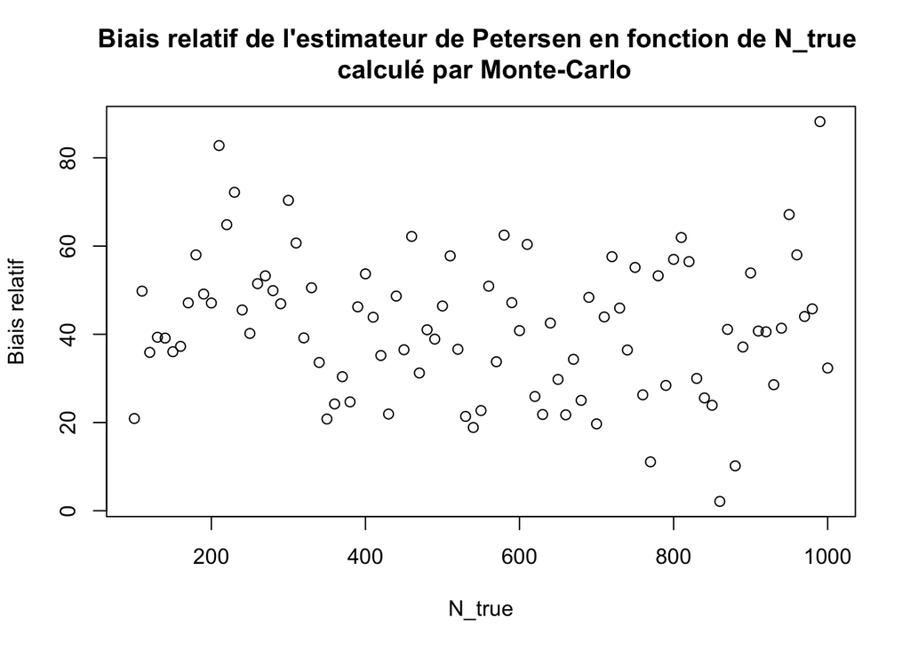

```r
#fonction qui effectue 100 réalisations du modèle M où N = N_true à choisir
# et pi = pi_true fixé
cent_est_fun <- function(N_true_par)
{
  return(replicate(n = 100, expr = realisations(N = N_true_par, prob = pi_true)))
}

N_true_tab <- seq(100,1000,10) #tableaux des valeurs de N_true
biais_tab <- rep(0,91) #tableau vide à remplir des biais calculés pour chaque valeur de N_true
compteur <- 1 #compteur

for(N_true_elt in N_true_tab)
{
  cent_sim <- replicate(n = 100, expr = realisations(N = N_true_elt, prob = pi_true))
  cent_est <-mapply(estPetersen,cent_sim[1,1:100],cent_sim[2,1:100]+cent_sim[3,1:100],cent_sim[3,1:100])
  biais_tab[compteur] <- mean(cent_est)
  compteur <- compteur + 1
}

#Biais relatif de l'estimateur de Petersen en fonction de N_true calculé par Monte-Carlo
plot(N_true_tab,biais_tab-N_true_tab,main="Biais relatif de l'estimateur de Petersen en fonction de N_true \n calculé par Monte-Carlo", xlab ="N_true", ylab="Biais relatif")
```

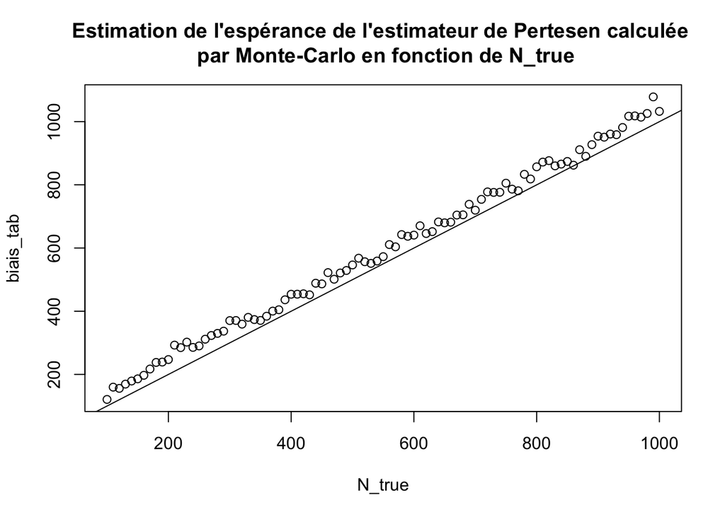

```r
#Estimation de l'espérance de l'estimateur de Pertesen calculée par Monte-Carlo en fonction de N_true
plot(N_true_tab,biais_tab,main="Estimation de l'espérance de l'estimateur de Pertesen calculée \n par Monte-Carlo en fonction de N_true",xlab="N_true",y_lab="Estimation de l'espérance")

abline(a = 0, b=1) #première bissectrice
```

Tout d’abord, sur le second graphique, on remarque que l’estimateur $\hat{I}_n$ s’étire sur une droite. Cette droite semble parallèle à la première bissectrice avec une translation verticale positive. A première vue, on voit que le biais relatif calculé par Monte-Carlo n’est pas nul le long des valeurs de $N_{true}$ mais semble borné et positif. On retrouve le même résultat sur le premier graphique où le biais semble positif et borné le long des valeurs de $N_{true}$.

On en conclut que l’estimateur de Petersen est biaisé. De plus, la plupart du temps, on trouve empiriquement $\mathbb{E}[\hat{N}] - N > 0$, c’est-à-dire que l’estimateur de Petersen semble sur-estimer la valeur de $N_{true}$.

### Approche bayésienne

Considérons une loi a priori $beta(\alpha= 1,\beta= 3)$ pour $\pi$ et une loi uniforme sur l’ensemble fini d’entiers $\{1,...,2000\}$ pour $N$.

$$\\[0.1cm]$$

**Question 9 :** La question 5. a montré que la loi conditionnelle complète de $\pi$ est : $\pi|N,y∼Beta(C_1+C_2+\alpha,2N-C_1-C_2+\beta)$. Donner l’expression de la loi conditionnelle complète de $N$ (à une constante multiplicative près). Reconnaissez-vous une forme analytique connue ?

$$\\[0.1cm]$$

On commence par écrire la loi jointe des observations $C_1, C_{20}, C_{21}$ et des paramètres $N$ et $\pi$. On note $y = (C_1, C_{20}, C_{21})$. On utilise la $\verb!chain rule!$ :

$$\begin{align}
[\pi, N, y] & = [y | \pi, N] \cdot [\pi, N] \\
& = [y | \pi, N] \cdot [N | \pi] \cdot [\pi]
\end{align}$$

et comme $N \sim U(\{ 1,...,2000 \})$ ne dépend pas de $\pi$ (a priori), on a $[N | \pi] = [N]$. Finalement :

$$[\pi, N, y] = [y | \pi, N] \cdot [N] \cdot [\pi]$$

Pour trouver la loi conditionnelle complète $[N | \pi, y]$ de $N$, il suffit d’isoler les termes indépendants de $N$ dans l’expression de $[\pi, N, y]$, car

$$[N | \pi, y] = \frac{[N, \pi, y]}{[\pi, y]}$$
et si l’on fixe $\pi$ et $y$ connues, le terme $1/[\pi, y]$ est une constante qui peut être intégrée à la constante de normalisation. On connait $[ \pi ]$ et $[y | \pi, N]$. De plus, $[N] = \frac{1}{2000} 1_{\{1,...,2000\}}(N)$, donc

$$\begin{align}
[\pi, N, y] & \propto C_N^{c_1}C_{N-c_1}^{c_{20}}C_{c_1}^{c_{21}} \cdot \pi^{c_1 + c_2} \cdot (1 - \pi)^{2N - c_1 - c_2} \cdot 1_{\{1,...,2000\}}(N) \cdot (1-\pi)^2 \\
& \propto C_N^{c_1}C_{N-c_1}^{c_{20}}C_{c_1}^{c_{21}} \cdot \pi^{c_1 + c_2} \cdot (1 - \pi)^{2(N+1) - c_1 - c_2} \cdot 1_{\{1,...,2000\}}(N) \\
& \propto C_N^{c_1}C_{N-c_1}^{c_{20}} \cdot \pi^{c_1 + c_2} \cdot (1 - \pi)^{2(N+1) - c_1 - c_2} \cdot 1_{\{1,...,2000\}}(N) \\
& \propto \frac{N!}{(N-c_1)! c_1 !} \cdot \frac{(N-c_1)!}{(N-c_1 - c_{20})! c_{20} !} \cdot (1 - \pi)^{2(N+1) - c_1 - c_2} \cdot 1_{\{1,...,2000\}}(N) \\
& \propto \frac{N!}{c_1 ! c_{20} ! (N- c_1 -c_{20})!} (1-\pi)^{2(N+1)-(c_1 + c_{20})} \pi^{c_1 + c_{20}} \cdot 1_{\{1,...,2000\}}(N)
\end{align}$$

On peut changer les quantités associées à $\pi$, $c_1$, $c_2$ comme on veut, en les intégrant à la constante de normalisation. Ainsi, on peut transformer
$$\frac{N !}{c_{1} ! c_{20} !\left(N-c_{1}-c_{20}\right) !} \to {N \choose c_1 + c_{20}} \quad \text{en faisant} \quad \frac{1}{c_1!c_{20}!} \to \frac{1}{(c_1 + c_{20})!}$$
$$(1-\pi)^{2(N+1)-\left(c_{1}+c_{20}\right)} \to (1 - \pi)^{2N} \quad \text{en faisant} (1 - \pi)^{2 - (c_1 + c_{20})} \to 1$$

Finalement

$$[N | \pi, y] \propto C_N^{c_1 + c_{20}} (1-\pi)^{2N} \pi^{c_1 + c_{20}} 1_{\{1,...,2000\}}(N)$$

Plusieurs articles, comme [Castledine, 1981], [Lee, 2003] identifient cette loi comme étant une binomiale. Pourtant, nous n’avons pas réussi à identifier les paramètres pour l’écrire comme cela. La fonction dessus est très instable numériquement. On peut améliorer cela en identifiant une loi beta comme facteur :

$$\begin{align}
C_N^{c_1 + c_{20}} (1-\pi)^{2N} \pi^{c_1 + c_{20}}
&= \frac{\Gamma(N+1)}{\Gamma(c_1 + c_{20} +1) \Gamma(N - c_1 - c_{20})} (1-\pi)^{2N - c_1 -c_{20} - 1} \pi^{c_1 + c_{20}}\\
&= (1-\pi)^N \cdot \beta_\pi (c_1 + c_{20} +1, N - c_1 - c_{20})
\end{align}$$

où nous avons changé des constantes qui dépendent que de $\pi, c_1, c_{20}$ si nécessaire. C’est cette fonction que l’on utilisera dans notre code comme posteriori.

$$\\[0.1cm]$$

**Question 10 :** Implémenter un algorithme MCMC sous la forme d’une fonction R nommée MCMC qui va permettre d’échantillonner dans la loi jointe a posteriori du couple $(N,\pi)$ sachant les données $y = (c_1,c_{20},c_{21})$ en mettant à jour :

- le paramètre $\pi$ avec un échantillonneur de Gibbs
- le paramètre $N$ avec un échantillonneur de Metropolis-Hastings (MH), en utilisant comme loi de proposition une loi uniforme (discrète) sur $\{N^{curr}-k,N^{curr}+k\}$ où $N$ curr désigne la valeur courante du paramètre $N$ à une itération donnée et $k$ est un paramètre de saut.

$$\\[0.1cm]$$

On commence par fixer les paramètres globaux : $\verb!borne.N!$ la borne maximale des valeurs possibles de $N$, $\verb!alpha! = 1$ et $\verb!beta! = 3$ les paramètres de la loi a priori de $\pi$. On construit également 2 fonctions auxiliaires : $\verb!echant.posteriori.pi!$ qui crée un échantillon de la loi a posteriori de $\pi$ et $\verb!posteriori.N!$ qui crée un échantillon de la loi a posteriori de $N$. Ces fonctions vont être utiles dans la fonction $\verb!MCMC!$.

```r
# Paramètres globaux
borne.N <- 2000
alpha <- 1
beta  <- 3

# Fonctions auxiliaires

# Échantilloneur a posteriori de param.pi
echant.posteriori.pi <- function(N, c1, c20, c21){
  rbeta(1, c1 + (c20 + c21) + alpha, 2*N - c1 - (c20 + c21) + beta)
}

# Échantilloneur a posteriori de param.pi
posteriori.N <- function(N, param.pi, c1, c20){

    res <-  (N >= 1 && N <= 2000) * dbeta(x = param.pi, shape1 = c1 + c20, shape2 = N - c1 - c20) * (1 - param.pi)^N

  return(res)
}
```

```r
# Fonction échantillonage du couple (N, param.pi)

# param.pi sera mis a jour avec echantilloneur de Gibbs

# N sera mis a jour avec Metropolis-Hastings (MH)
# de loi de proposition une loi uniforme (discrete)
# sur {N_curr - k, N_curr + k}

MCMC <- function(k, c1, c20, c21, niter){
  #tableaux à remplir
  chain.N <- matrix(0, niter + 1, 1)
  chain.param.pi <- matrix(0, niter + 1, 1)
  accept <- matrix(0, niter + 1, 1)

  # Étape 0 : valeurs initiales

  # Loi a priori de param.pi est une beta
  param.pi <- rbeta(1, alpha, beta)
  chain.param.pi[1,1] <- param.pi

  # Loi a priori de N est uniforme
  N <- sample(c((c1 + c20):borne.N), size = 1)
  chain.N[1,1] <- N

  accept[1,1] <- 1

  for (i in c(1:niter)) {

    # Mise a jour de N
    N.candidat   <- N + sample(-k:k, 1)

    #Calcul du ratio de-Metropolis Hastings
    numerateur   <- posteriori.N(N.candidat, param.pi = param.pi, c1 = c1, c20 = c20)

    denominateur <- posteriori.N(N, param.pi = param.pi, c1 = c1, c20 = c20)

    r <- numerateur/denominateur

    #calcul de l'acceptation
    u <- runif(n = 1)

    if ((!is.na(r)) && (u < r)) {
      N <- N.candidat
      accept[i + 1, 1] <- 1
    }

    chain.N[i + 1, 1] <- N

    # Mise a jour de pi
    param.pi <- echant.posteriori.pi(N, c1, c20, c21)
    chain.param.pi[i + 1,1] <- param.pi

  }

  # 2 choix de return possible selon le format souhaité :
  #return(cbind(chain.N, chain.param.pi))
  return(mcmc(matrix(c(chain.N, chain.param.pi,    accept),nrow=niter+1,ncol=3,byrow=FALSE)))
}
```

On peut tester cette fonction en créant une réalisation $y$, grâce à la fonction $\verb!realisations!$, et en appliquant notre fonction $\verb!MCMC!$.

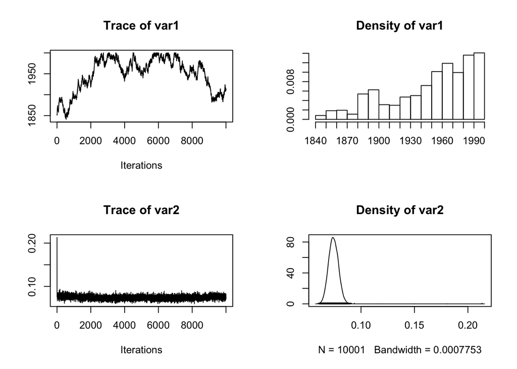

```r
# Créeons une réalisation pour N = 900, pi = 0.4
y <- realisations(923, 0.15)
c1 <- y[1]
c20 <- y[2]
c21 <- y[3]
niter <- 10000

# TEST
test.mcmc <- MCMC(k = 2, c1 = c1, c20 = c20, c21 = c21, niter = niter)
plot(test.mcmc[,c(1,2)])
```

$$\\[0.1cm]$$

**Question 11 :** Choix du saut $k$ : Utiliser la fonction MCMC précédemment implémentée pour calculer puis tracer l’évolution du taux d’acceptation associé à la mise à jour de $N$ en fonction de différentes valeurs du paramètre $k$ (par exemple, allant de 1 à 301 par pas de 10). Pour chaque valeur de $k$,on pourra faire tourner l’algorithme MCMC pendant 10 000 itérations et qu’avec une seule chaîne de Markov pour cette étape de calibration. Quelle valeur de $k$ vous semble la meilleure (rappel : viser un taux d’acceptation d’environ 40%) ? Vous conserverez cette valeur pour la suite.

$$\\[0.1cm]$$

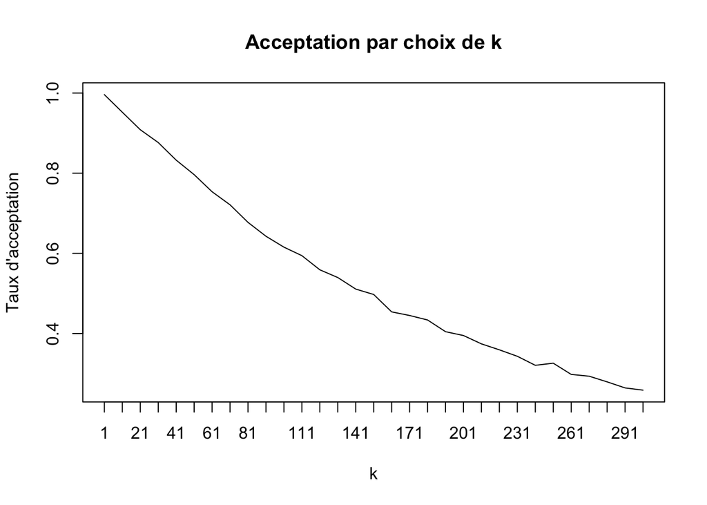

```r
k.possib <- seq(from = 1, to = 301, by = 10)
donnees <- sapply(k.possib, MCMC, c1 = c1, c20 = c20, c21 = c21, niter = niter)

taille.donnees <- dim(donnees)[1]

#On récupère les données relatives à N
donnees.N <- donnees[c(1:taille.donnees/3),]

#idem pour pi
donnees.param.pi <- donnees[c((taille.donnees/3 + 1):(2*(taille.donnees/3))),]

#idem pour le taux d'acceptation
donnees.taux <- apply(tail(donnees, n = niter), MARGIN = 2, FUN = sum)/niter

plot(donnees.taux, type = 'l', main = 'Acceptation par choix de k', ylab = 'Taux d\'acceptation', xaxt = 'n', xlab = "k")
axis(side = 1, at = 1:31,labels = k.possib)
```

```r
# Choix du bon k
k <- k.possib[which.min(abs(donnees.taux - 0.4))]
print(k)
```

```
## [1] 191
```

On voit que le graphe a le comportement attendu, c’est-à-dire, quand $k$ est trop petit on accepte fréquemment, et quand $k$ devient très grand on accepte très peu. Pour sélectionner $k$, on a pris celui qui donne le taux d’acceptation le plus proche de $0.4$, le critère vu en cours.

$$\\[0.1cm]$$

**Question 12 :** Lancer à présent 3 chaînes de Markov à partir de positions initiales différentes en fixant $k$ à la valeur précedemment choisie afin de générer 3 échantillons $((N^{(1)},\pi^{(1)}),...,(N^{(G)},\pi^{(G)}))$ de taille $G= 20 000$. Faites un examen visuel des chaînes de Markov obtenues et calculer la statistique de Gelman-Rubin. Identifiez-vous un problème de convergence de l’algorithme MCMC implémenté vers sa loi stationnaire ? Si oui, comment proposez-vous d’y remédier ? Combien d’itérations $X$ vous semblent a minima nécessaires pour espérer avoir atteint l’état stationnaire ?

$$\\[0.1cm]$$

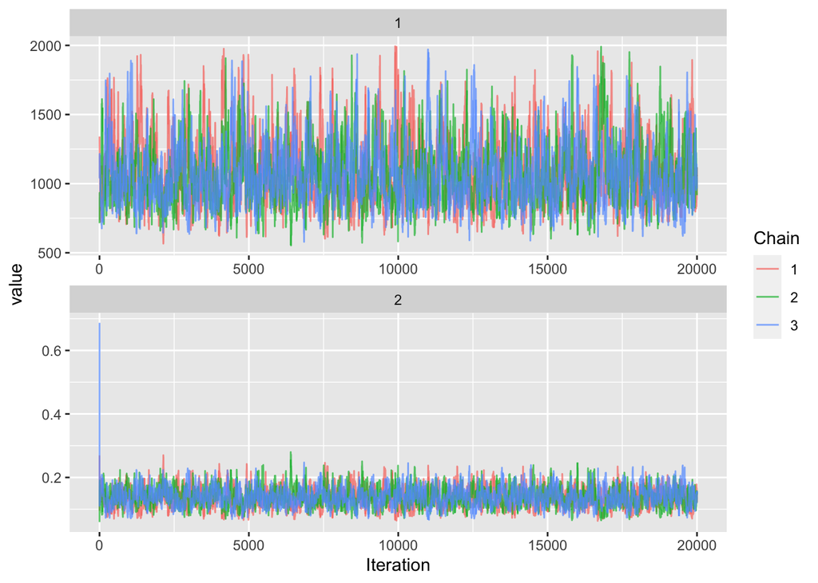

```r
niter = 20000

y <- realisations(923, 0.15)
c1 <- y[1]
c20 <- y[2]
c21 <- y[3]

chaine.1 <- MCMC(k = k, c1 = c1, c20 = c20, c21 = c21, niter = niter)

chaine.2 <- MCMC(k = k, c1 = c1, c20 = c20, c21 = c21, niter = niter)

chaine.3 <- MCMC(k = k, c1 = c1, c20 = c20, c21 = c21, niter = niter)

mcmc.chains <- mcmc.list(list(chaine.1,chaine.2,chaine.3))

# Analyse visuelle
model.samples.gg <- ggs(mcmc.chains)
ggs_traceplot(model.samples.gg)
```

On remarque que les trois chaînes convergent vers la même valeur car elles se confondent à partir d’une certaine itération. Cette observation visuelle ne nous permet pas de conclure définitivement sur la nature de la convergence. C’est pourquoi on utilise un autre diagnostic, le critère de Gelman-Rubin. Ce critère ne nous permet également pas de conclure sur la nature de la convergence mais c’est un outil supplémentaire dans son étude.

```r
# Statistique de Gelman-Rubin
gelman.diag(mcmc.chains)
```

```
## Potential scale reduction factors:
##
##      Point est. Upper C.I.
## [1,]       1.00       1.02
## [2,]       1.01       1.02
##
## Multivariate psrf
##
## 1.01
```

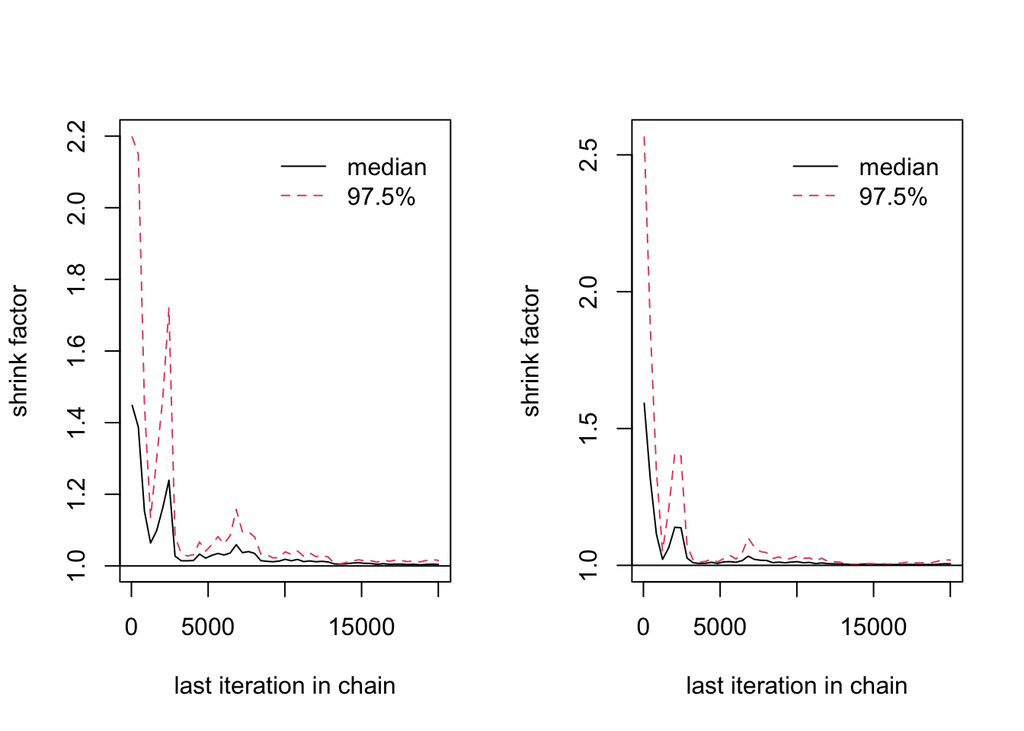

```r
gelman.plot(mcmc.chains)
```

Idéalement, les statistiques de Gelman-Rubin doivent être inférieures à $1.05$ (et elles sont toujours supérieures à $1$) et être stables. On vérifie visuellement la stabilité des chaînes. Si ce n’était pas le cas, on pourrait essayer d’augmenter le nombre d’itérations pour y remédier.

Finalement, on considère arbitrairement que l’on a besoin de $X = 15 000$ itérations pour espérer atteindre l’état stationnaire, c’est-à-dire 75% des itérations. On verra que les ESS associés à ce choix de $X$ sont satisfaisants, c’est notamment pour cela que l’on choisi $X = 15 000$.

$$\\[0.1cm]$$

**Question 13 :** Analyser les autocorrélations intra-chaînes. Qu’en pensez-vous ?

$$\\[0.1cm]$$

On continue l’étude de la convergence de notre algorithme avec l’analyse de l’autocorrélation intra-chaîne. On utilise les fonctions $\verb!autocorr.diag!$ et $\verb!autocorr.plot!$ de la librairie $\verb!coda!$.

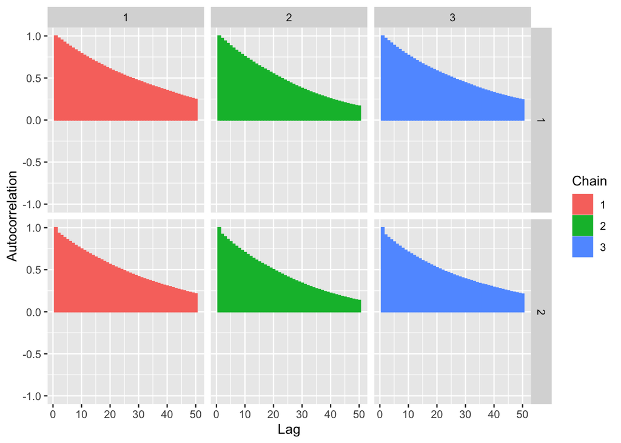

```r
# Diagnostiques du package mcmc
# autocorr.diag(mcmc.chains)
# autocorr.plot(mcmc.chains)

# Graphes du package ggmcmc
ggs_autocorrelation(model.samples.gg)
```

Les graphiques d’autocorrélations intra-chaînes ont une bonne allure. Elles diminuent exponentiellement dans tous les cas. Si les chaînes étaient corrélées, on n’observerai pas cette décroissance exponentielle et beaucoup plus de valeurs après le temps de chauffe seraient nécessaires pour bien approcher la loi à posteriori, ce qui coûterait énormément de temps de calcul. Dans notre cas, ce n’est pas le cas et on est satisfait de notre résultat.

$$\\[0.1cm]$$

**Question 14 :** Supprimer les $X$ premières itérations correspondant à votre temps-de-chauffe “estimé” de l’algorithme afin de constituer votre échantillon a posteriori. Calculer la taille d’échantillon effective (ESS) de l’échantillon a posteriori constitué. Qu’en pensez-vous ? Si l’ESS vous semble trop petit, refaites tourner l’algorithme en augmentant le nombre d’itérations $G$ jusqu’à obtenir un ESS “satisfaisant” pour bien estimer $N$ et $\pi$.

$$\\[0.1cm]$$
On assume que seulement les $25\%$ dernières itérations seront “utiles” et les autres sont comprises dans le temps de chauffe.

```r
niter.supprim <- round((0.75)*niter)
print(paste('La taille d\'itérations utilisées est', niter - niter.supprim))
```

```
## [1] "La taille d'itérations utilisées est 5000"
```

On calcule maintenant la taille d’échantillon effective (ESS) de l’échantillon a posteriori constitué :

```r
#Création d'une chaîne sur l'échantillon réduit :
mcmc.chains.reduites <- mcmc.list(list(tail(chaine.1, n = niter - niter.supprim),
                                       tail(chaine.2, n = niter - niter.supprim),
                                       tail(chaine.3, n = niter - niter.supprim)))

# Regardons de nouveau les diagnostiques
gelman.diag(mcmc.chains.reduites)
```

```
## Potential scale reduction factors:
##
##      Point est. Upper C.I.
## [1,]       1.01       1.03
## [2,]       1.01       1.04
##
## Multivariate psrf
##
## 1.01
```

```r
effectiveSize(mcmc.chains.reduites)
```

```
##     var1     var2
## 223.5231 267.1504
```

On utilise les $5000$ dernières itérations, et pourtant les valeurs des ESS sont beaucoup plus faibles (environ 200 à 400). Ces valeurs de ESS sont suffisamment importantes pour que l’on considère que l’algorithme a convergé, d’après certains critères arbitraires d’interprétation de ESS vus sur internet. En fait, on a besoin que les valeurs de ESS soient assez élevées pour conserver l’hypothèse d’indépendance des variables dans la convergence de l’estimateur de Monte-Carlo. Ici, nos valeurs de ESS nous semblent satisfaisantes mais si on veut qu’elles soient plus importantes, alors on peut augmenter le nombre d’itérations $G$.

$$\\[0.1cm]$$

**Question 15 :** Donner les statistiques a posteriori et représenter les lois a posteriori approchées pour les paramètres inconnus de votre modèle. Comparer les résultats obtenus à ceux obtenus avec une approche fréquentiste.

$$\\[0.1cm]$$

Pour calculer les statistiques a posteriori, on utilise la librairie $\verb!rjags! .$. On compare l’erreur de Monte-Carlo avec l’écart-type à posteriori empirique. Idéalement, l’erreur doit être plus pétite que $0.05 \hat{\sigma}$.

```r
print(summary(mcmc.chains.reduites))
```

```
##
## Iterations = 15001:20001
## Thinning interval = 1
## Number of chains = 3
## Sample size per chain = 5001
##
## 1. Empirical mean and standard deviation for each variable,
##    plus standard error of the mean:
##
##           Mean        SD  Naive SE Time-series SE
## [1,] 1071.5195 226.52365 1.8493730      15.169224
## [2,]    0.1358   0.02796 0.0002283       0.001725
##
## 2. Quantiles for each variable:
##
##          2.5%      25%       50%       75%     97.5%
## [1,] 729.0000 909.0000 1036.0000 1193.0000 1618.0000
## [2,]   0.0854   0.1161    0.1347    0.1543    0.1942
```

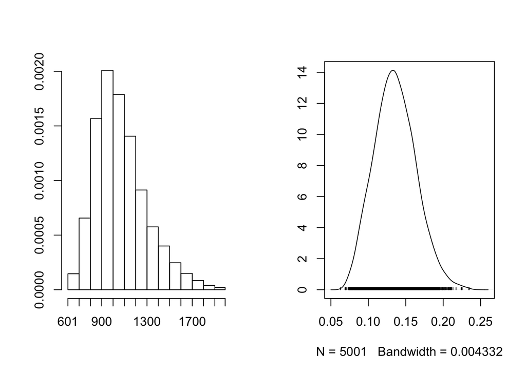

```r
plot(mcmc.chains.reduites, density=TRUE, trace=FALSE)
```

## Conclusion

Dans ce projet, nous avons appliqué différentes méthodes et approches d’estimation de paramètres dans le cadre des méthodes de capture-marquage-recapture. Après avoir posé et étudié le problème, nous avons créer une fonction générant des réalisations que l’on a utilisée dans la suite du projet. Nous avons calculé des estimations des paramètres $N$ et $\pi$ selon différents cas de connaissance de $N$ et de $\pi$ et selon une approche fréquentiste et une approche bayésienne. L’approche fréquentiste s’est basée sur l’estimateur de Petersen, utilisé dans les méthodes de capture-marquage-recapture. Dans l’approche bayésienne, on a utilisé un algorithme MCMC. Cela nous a permis d’appréhender son utilisation et d’étudier ses résultats.

## Références

B. J. CASTLEDINE, A Bayesian analysis of multiple-recapture sampling for a closed population, Biometrika, Volume 68, Issue 1, April 1981, Pages 197–210, https://doi.org/10.1093/biomet/68.1.197

LEE, Shen-Ming, HWANG, Wen-Han, et HUANG, Li-Hui. Bayes estimation of population size from capture-recapture models with time variation and behavior response. Statistica Sinica, 2003, p. 477-494.